```python
import numpy as np, pandas as pd
from IPython.display import HTML
```

# The Journey of a developer

| [*Home*](https://antonio-catalano.github.io/) | [*About*](https://antonio-catalano.github.io/about.html) | [*Archive*](https://antonio-catalano.github.io/Archive.html) |  |
| --- | --- | --- | --- |

# Studio Popolazione e mortalità infantile

### Prendiamo il database generale dalla 'World Bank Open Data', un database che riguarda tutti i Paesi e le zone strategiche del mondo, per una serie di indicatori che vanno dal 1960 al 2016.

### Selezioniamo l'indicatore relativo alla Popolazione. Vediamo sotto le prime cinque zone strategiche del database e la corrispondente popolazione dal 1960 al 2016.

```python
popTot = df2[df2['Indicator Name']=='Population, total']
popTot = popTot.reindex(columns = popTot.columns[:-2])
popTot.head()
```

| Country Name | Indicator Name | 1960 | 1961 | 1962 | 1963 | 1964 | 1965 | 1966 | 1967 | 1968 | ... | 2007 | 2008 | 2009 | 2010 | 2011 | 2012 | 2013 | 2014 | 2015 | 2016 |
| --- | --- | --- | --- | --- | --- | --- | --- | --- | --- | --- | --- | --- | --- | --- | --- | --- | --- | --- | --- | --- | --- |
| Arab World | Population, total | 92490932.00 | 95044497.00 | 97682294.00 | 100411076.00 | 103239902.00 | 106174988.00 | 109230593.00 | 112406932.00 | 115680165.00 | ... | 331653797.00 | 339825483.00 | 348145094.00 | 356508908.00 | 364895878.00 | 373306993.00 | 381702086.00 | 390043028.00 | 398304960.00 | 406452690.00 |
| Caribbean small states | Population, total | 4198307.00 | 4277802.00 | 4357746.00 | 4436804.00 | 4513246.00 | 4585777.00 | 4653919.00 | 4718167.00 | 4779624.00 | ... | 6851221.00 | 6895315.00 | 6939534.00 | 6984096.00 | 7029022.00 | 7074129.00 | 7118888.00 | 7162679.00 | 7204948.00 | 7245472.00 |
| Central Europe and the Baltics | Population, total | 91401583.00 | 92237118.00 | 93014890.00 | 93845749.00 | 94722599.00 | 95447065.00 | 96148635.00 | 97043587.00 | 97882394.00 | ... | 105504531.00 | 105126686.00 | 104924372.00 | 104543801.00 | 104174038.00 | 103935318.00 | 103713726.00 | 103496179.00 | 103257751.00 | 102991323.00 |
| Early-demographic dividend | Population, total | 979287407.00 | 1002523576.00 | 1026586722.00 | 1051414973.00 | 1077037307.00 | 1103433059.00 | 1130587356.00 | 1158571169.00 | 1187273756.00 | ... | 2778276175.00 | 2821797496.00 | 2865439651.00 | 2909410986.00 | 2953406021.00 | 2997066325.00 | 3040700765.00 | 3084236443.00 | 3127578757.00 | 3170657660.00 |
| East Asia & Pacific | Population, total | 1039944591.00 | 1043546746.00 | 1058028198.00 | 1083802302.00 | 1109204182.00 | 1135650893.00 | 1165517897.00 | 1194424325.00 | 1223721287.00 | ... | 2162102842.00 | 2177421109.00 | 2192351452.00 | 2207154891.00 | 2221934234.00 | 2237082761.00 | 2252310372.00 | 2267745316.00 | 2283107673.00 | 2298727229.00 |

5 rows × 58 columns

Analizziamo quali sono le zone strategiche e i Paesi dove c'è stato un maggiore incremento della popolazione in valore assoluto tra il 1960 e il 2016.  
Gli Stati in cui la popolazione è aumentata maggiormente in valore assoluto sono l'India (un incremento di 874,7 milioni negli ultimi 56 anni), seguita dalla Cina (un incremento di 711 milioni).  
Terza l'Indonesia con un incremento di 173 milioni di persone.  
Qui sotto vediamo le 50 zone geografiche/ gruppi socio-economici/ Stati, la cui popolazione è piu' aumentata tra il 1960 e il 2016.

```python
pd.set_option('display.float_format', lambda x: '%.2f' % x)

def f_1960_2016(df):
    return df['2016']-df['1960']

def highlight(s):
    return ['background-color: lightgreen' if elem in ['India','China','Indonesia'] else '' for elem in s.index]

ordinePop = f_1960_2016(popTot).sort_values(ascending=False).head(50)

ordinePop = ordinePop.to_frame().rename(columns={0:'Incremento Popolazione 1960-2016'})
#ordinePop.style.set_properties(subset=['Incremento Popolazione 1960-2016'], **{'background-color': 'pink'})

styled = ordinePop.style.apply(highlight)
c = styled.format({'Incremento Popolazione 1960-2016': "{:.2f}"})
c
```

| Country Name | Incremento Popolazione 1960-2016 |
| --- | --- |
| World | 4411866832.00 |
| Low & middle income | 3976522496.00 |
| Middle income | 3471919983.00 |
| Early-demographic dividend | 2191370253.00 |
| Lower middle income | 2061351758.00 |
| Upper middle income | 1410568225.00 |
| East Asia & Pacific | 1258782638.00 |
| South Asia | 1194558048.00 |
| South Asia (IDA & IBRD) | 1194558048.00 |
| Late-demographic dividend | 1167345130.00 |
| East Asia & Pacific (excluding high income) | 1159342799.00 |
| East Asia & Pacific (IDA & IBRD countries) | 1145374630.00 |
| India | 874690746.00 |
| Sub-Saharan Africa | 804626738.00 |
| Sub-Saharan Africa (IDA & IBRD countries) | 804626738.00 |
| Sub-Saharan Africa (excluding high income) | 804573761.00 |
| Least developed countries: UN classification | 738645729.00 |
| China | 711595000.00 |
| Pre-demographic dividend | 690656262.00 |
| Heavily indebted poor countries (HIPC) | 582107396.00 |
| Low income | 504602513.00 |
| OECD members | 501163511.00 |
| High income | 435344336.00 |
| Latin America & Caribbean | 417234015.00 |
| Latin America & the Caribbean (IDA & IBRD countries) | 411177301.00 |
| Latin America & Caribbean (excluding high income) | 403847931.00 |
| Fragile and conflict affected situations | 383870950.00 |
| Post-demographic dividend | 347946104.00 |
| Middle East & North Africa | 331231415.00 |
| Arab World | 313961758.00 |
| Middle East & North Africa (excluding high income) | 275881289.00 |
| Middle East & North Africa (IDA & IBRD countries) | 271329723.00 |
| Europe & Central Asia | 244600894.00 |
| Indonesia | 173322941.00 |
| North America | 160833084.00 |
| Pakistan | 148295183.00 |
| Europe & Central Asia (IDA & IBRD countries) | 146651305.00 |
| United States | 142456513.00 |
| Nigeria | 140851828.00 |
| Europe & Central Asia (excluding high income) | 138318668.00 |
| Brazil | 135445311.00 |
| Bangladesh | 114751813.00 |
| European Union | 101862469.00 |
| Mexico | 89366311.00 |
| Ethiopia | 80251918.00 |
| Philippines | 77047197.00 |
| Euro area | 75365845.00 |
| Egypt, Arab Rep. | 68692148.00 |
| Congo, Dem. Rep. | 63487902.00 |
| Vietnam | 61898443.00 |

**Per quanto riguarda la popolazione italiana, dal 1960 al 2016 è aumentata di piu' di 10 milioni. Un incremento del 20%.**

```python
print('Incremento popolazione italiana 1960-2016 :', f_1960_2016(popTot).sort_values(ascending=False)['Italy'])
```

```
Incremento popolazione italiana 1960-2016 : 10427798.0
```

**Qui sotto abbiamo la conferma che ci fa vedere l'andamento anno per anno della nostra nazione.**

```python
popTot.loc['Italy'].to_frame().T
```

|  | Indicator Name | 1960 | 1961 | 1962 | 1963 | 1964 | 1965 | 1966 | 1967 | 1968 | ... | 2007 | 2008 | 2009 | 2010 | 2011 | 2012 | 2013 | 2014 | 2015 | 2016 |
| --- | --- | --- | --- | --- | --- | --- | --- | --- | --- | --- | --- | --- | --- | --- | --- | --- | --- | --- | --- | --- | --- |
| Italy | Population, total | 50199700.00 | 50536350.00 | 50879450.00 | 51252000.00 | 51675350.00 | 52112350.00 | 52519000.00 | 52900500.00 | 53235750.00 | ... | 58438310.00 | 58826731.00 | 59095365.00 | 59277417.00 | 59379449.00 | 59539717.00 | 60233948.00 | 60789140.00 | 60730582.00 | 60627498.00 |

1 rows × 58 columns

```python
print('Italy: 1960->',popTot.loc['Italy']['1960'],' 2016->',popTot.loc['Italy']['2016'])
```

```
Italy: 1960-> 50199700.0  2016-> 60627498.0
```

Andiamo a vedere ora quali sono i Paesi dove la popolazione è piu' aumentata in termini relativi e non assoluti.  
Studiamo quindi l'andamento dei tassi di incremento della popolazione dal 1960 al 2016.

```python
def deltaperc(df):
    return (df['2016']-df['1960']) / df['1960']
```

N.B: i valori di cui sotto sono tassi. Quindi presta attenzione quando li converti in percentuali.  
Gli Emirati Arabi sono ad. esempio lo Stato che piu' è aumentato in termini relativi, con un tasso pari a 99. Cio' significa che la popolazione è aumentata del 9900 % rispetto al 1960.

```python
deltanew = deltaperc(popTot).sort_values(ascending = False).to_frame().rename(columns={0:'Tasso di incremento 1960-2016'})
deltanew.head(30)
```

| Country Name | Tasso di incremento 1960-2016 |
| --- | --- |
| United Arab Emirates | 99.07 |
| Qatar | 53.23 |
| Kuwait | 14.03 |
| Djibouti | 10.27 |
| Jordan | 9.14 |
| Bahrain | 7.77 |
| Oman | 7.02 |
| Saudi Arabia | 6.90 |
| Cayman Islands | 6.73 |
| St. Martin (French part) | 6.47 |
| Cote d'Ivoire | 5.66 |
| Uganda | 5.11 |
| Niger | 5.10 |
| Turks and Caicos Islands | 5.10 |
| Kenya | 4.98 |
| Andorra | 4.76 |
| Gambia, The | 4.54 |
| Tanzania | 4.52 |
| Northern Mariana Islands | 4.48 |
| Zambia | 4.45 |
| Yemen, Rep. | 4.33 |
| Sudan | 4.25 |
| Somalia | 4.20 |
| Brunei Darussalam | 4.18 |
| Congo, Dem. Rep. | 4.16 |
| Angola | 4.11 |
| Iraq | 4.10 |
| Solomon Islands | 4.09 |
| Mauritania | 4.01 |
| Malawi | 4.00 |

I due Stati dal maggior incremento relativo:  
1) Gli Emirati Arabi, da 92mila abitanti del 1960, sono passati a piu' di 9 milioni nel 2016. (un po' come Ancona che diventa New York in soli 56 anni)  
2) Il Qatar, da 47 mila abitanti del 1960, a piu' di 2 milioni e mezzo nel 2016. (un po' come Vasto che diventa Parigi)

```python
print('Emirati Arabi: 1960->',popTot.loc['United Arab Emirates']['1960'],' 2016->',popTot.loc['United Arab Emirates']['2016'])

print('Qatar: 1960->',popTot.loc['Qatar']['1960'],' 2016->',popTot.loc['Qatar']['2016'])
```

```
Emirati Arabi: 1960-> 92634.0  2016-> 9269612.0
Qatar: 1960-> 47384.0  2016-> 2569804.0
```

Mettiamo ora su grafico l'andamento assoluto della popolazione relativo a:  
1) Mondo  
2) India  
3) Cina  
4) Indonesia  
I primi 3 grafici sono scalati in miliardi (1e9 = 1 miliardo), mentre l'ultimo in centinaia di milioni (1e8 = 100 milioni).  
Da notare che Cina e India, da sole, costituiscono circa 1/3 dell'intera popolazione mondiale.

```python
import matplotlib.pyplot as plt

index = pd.to_datetime(popTot.loc['World'][1:].index)
```

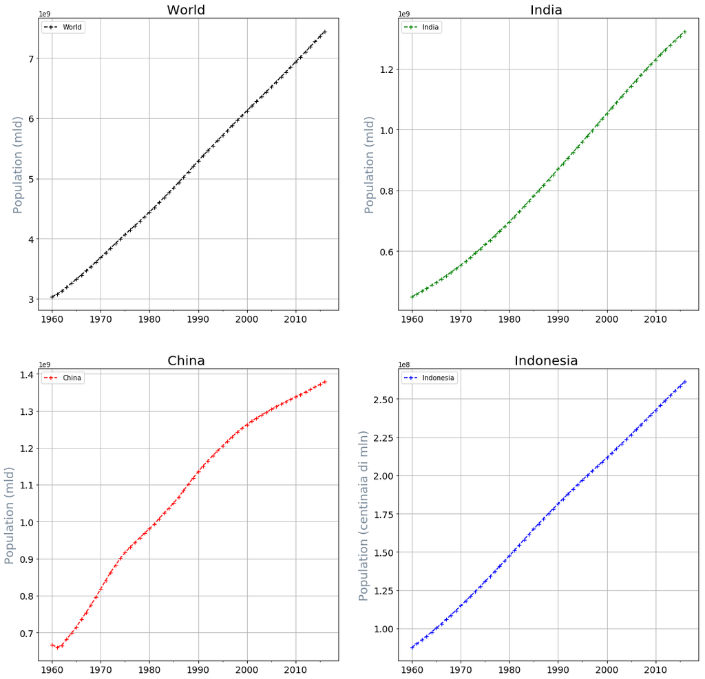

```python
fig, axes = plt.subplots(2,2, figsize=(18,18))
Grafici = []
Grafici.append(popTot.loc['World'][1:].to_frame().plot(x = index, ax = axes[0,0],grid=True, style='k+--'))
Grafici.append(popTot.loc['China'][1:].to_frame().plot(x = index, ax = axes[1,0],grid=True,style='r+--'))
Grafici.append(popTot.loc['India'][1:].to_frame().plot(x = index, ax = axes[0,1], grid=True,style='g+--'))#,logy=True))
Grafici.append(popTot.loc['Indonesia'][1:].to_frame().plot(x = index, ax = axes[1,1], grid=True,style='b+--'));#,logy=True))

lista = ['World','China','India','Indonesia']

for graph,elem in zip(Grafici,lista):
#     if elem=='World':
#         yticks = [2*10**9, 3*10**9, 4*10**9, 5*10**9, 6*10**9, 7*10**9, 8*10**9]
#         yticks = [str(e) for e in yticks]
#         graph.set_yticklabels(yticks, fontsize=14)
    graph.set_title('{} '.format(elem), fontsize=20, color = 'k')
    graph.tick_params(axis='both', labelsize = 14, labelcolor = 'k')
    if elem == 'Indonesia':
        graph.set_ylabel('Population (centinaia di mln)', fontsize=18, color = '#778899')
    else:
        graph.set_ylabel('Population (mld)', fontsize=18, color = '#778899')
```

```
             World        China        India
1960 3032160395.00 667070000.00 449480608.00
1961 3073368588.00 660330000.00 458494963.00
1962 3126509808.00 665770000.00 467852537.00
1963 3191786431.00 682335000.00 477527970.00
1964 3257459749.00 698355000.00 487484535.00

             World         China         India
2012 7099548883.00 1350695000.00 1263065852.00
2013 7185078354.00 1357380000.00 1278562207.00
2014 7271228017.50 1364270000.00 1293859294.00
2015 7357369754.00 1371220000.00 1309053980.00
2016 7444027227.00 1378665000.00 1324171354.00
```

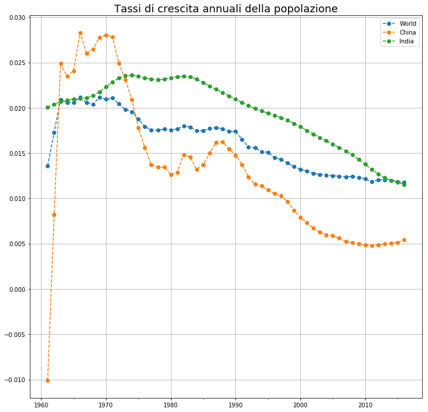

```python
fig, axes = plt.subplots(1,1, figsize=(12,12))
par = popTot.loc['World'][1:].to_frame().join([popTot.loc['China'][1:].to_frame(),popTot.loc['India'][1:].to_frame()])
par_perc = par.pct_change()
axes.set_title('Tassi di crescita annuali della popolazione', fontsize=18)
par_perc.plot(x = index, ax = axes, grid = True, style='o--');
#newticks = [str(i)+ ' mdl' for i in range(len(list(axes.get_yticklabels)))]
#newticks = [str(i)+ ' mld' for i in range(8)]
#axes.set_yticklabels(newticks)

print(par.head())
print()
print(par.tail())
print()
```

### Passiamo ora allo studio della mortalita' infantile.

Se possiamo ipotizzare che l'incremento relativo enorme della popolazione del mondo arabo sia conseguenza della valorizzazione delle loro risorse energetiche naturali come il petrolio, che hanno portato quei territori ad allinearsi alla ricchezza e allo stile di vita 'occidentale', trasformando alcuni citta' del mondo arabo in metropoli simili a quelle occidentali, per quanto riguarda l'incremento relativo della popolazione dell'Africa centrale, una possibile ipotesi è la diminuzione della mortalita' infantile.  
I dati che abbiamo relativi a questo indicatore pero' coprono solo gli ultimi 7 anni.  
Non molti, ma possiamo verificare se c'è comunque un trend netto in questi ultimi anni per quanto riguarda la mortalita' infantile in Africa.  
Se questa diminuisce anno per anno, allora si spiega meglio perche' la popolazione africana cresce con un'accelerazione maggiore di quasi tutto il resto del mondo.  
Prendiamo i dati sulla mortalita' infantile nel mondo dal 2009 al 2016.

```python
def f_2009_2016(df):
    return df['2016']-df['2009']
```

La tabella sotto mostra le prime cinque regioni del database relative alla mortalita'infantile.  
La statistica ci dice quanti bambini sotto i 5 anni muoiono su 1000 nascite.

```python
mort_rate = df2[df2['Indicator Name']=='Mortality rate, under-5 (per 1,000)']
anni = ['2009','2010','2011','2012','2013','2014','2015','2016']
mort_rate = mort_rate.reindex(columns = anni)
mort_rate.head()
```

| Country Name | 2009 | 2010 | 2011 | 2012 | 2013 | 2014 | 2015 | 2016 |
| --- | --- | --- | --- | --- | --- | --- | --- | --- |
| Arab World | 45.37 | 43.86 | 42.59 | 41.51 | 40.47 | 39.59 | 38.74 | 37.96 |
| Caribbean small states | 21.99 | 21.44 | 20.92 | 20.37 | 19.84 | 19.27 | 18.67 | 18.09 |
| Central Europe and the Baltics | 7.46 | 7.11 | 6.77 | 6.46 | 6.19 | 5.94 | 5.79 | 5.61 |
| Early-demographic dividend | 54.10 | 52.08 | 49.26 | 47.07 | 45.01 | 43.08 | 41.29 | 39.67 |
| East Asia & Pacific | 23.24 | 21.99 | 20.88 | 19.80 | 18.82 | 17.89 | 17.11 | 16.35 |

```python
peggioramenti = f_2009_2016(mort_rate).sort_values(ascending = False)
peggioramenti.head()
```

```
Country Name
Dominica               13.70
Grenada                 1.40
Macedonia, FYR          1.30
Syrian Arab Republic    1.10
Malaysia                0.40
dtype: float64
```

Se filtriamo invece gli Stati dove piu' si è abbassata la mortalita' infantile...i conti sembrano tornare.  
I Paesi africano sono quelli dove piu' si è abbassata la mortalita' infantile negli ultimi 7 anni.  
In Sierra Leone nel 2016, su 1000 nascite, muoiono 56 bambini in meno rispetto al 2009.  
La mortalita' infantile quindi in Africa si sta abbassando molto, e cio' conferma la nostra ipotesi iniziale.

```python
miglioramenti = f_2009_2016(mort_rate).sort_values()
miglioramenti.head(10)
```

```
Country Name
Sierra Leone   -56.10
Angola         -45.80
Malawi         -40.60
Niger          -40.30
Burkina Faso   -39.00
Zimbabwe       -38.50
Cameroon       -34.80
Swaziland      -34.50
Mozambique     -34.40
Uganda         -33.40
dtype: float64
```

**Andamento mortalita' infantile 2009-2016 in Sierra Leone:**

```python
mort_rate = mort_rate.reindex(columns = anni)

mort_rate.loc['Sierra Leone']
```

```
2009   169.60
2010   159.70
2011   149.80
2012   140.40
2013   132.00
2014   124.90
2015   118.80
2016   113.50
Name: Sierra Leone, dtype: float64
```

Cio' non significa ovviamente che la situazione sia rosea in Africa. E' ancora la regione che presenta di gran lunga i piu' alti tassi di mortalita' infantile, nonostante gli evidenti miglioramenti degli ultimi 7 anni.  
Sotto possiamo osservare gli Stati che hanno la mortalita' infantile piu' elevata nel mondo.  
L'Africa ha ancora tassi molto alti.

```python
high_mort_rate = mort_rate.sort_values(by='2016', ascending = False)
```

```python
high_mort_rate.head(20)
```

| Country Name | 2009 | 2010 | 2011 | 2012 | 2013 | 2014 | 2015 | 2016 |
| --- | --- | --- | --- | --- | --- | --- | --- | --- |
| Somalia | 163.70 | 159.20 | 154.40 | 149.80 | 145.20 | 140.70 | 136.70 | 132.50 |
| Chad | 153.70 | 149.70 | 145.70 | 141.80 | 138.10 | 134.50 | 130.90 | 127.30 |
| Central African Republic | 152.70 | 148.90 | 145.20 | 141.30 | 137.70 | 133.60 | 128.80 | 123.60 |
| Sierra Leone | 169.60 | 159.70 | 149.80 | 140.40 | 132.00 | 124.90 | 118.80 | 113.50 |
| Mali | 141.70 | 136.50 | 131.30 | 126.60 | 122.10 | 118.30 | 114.20 | 110.60 |
| Nigeria | 134.80 | 129.60 | 124.60 | 120.00 | 115.60 | 111.60 | 108.00 | 104.30 |
| Benin | 113.20 | 111.10 | 109.20 | 107.20 | 105.10 | 102.80 | 100.30 | 97.60 |
| Congo, Dem. Rep. | 119.60 | 115.60 | 111.70 | 108.10 | 104.40 | 101.00 | 97.60 | 94.30 |
| Lesotho | 103.40 | 99.70 | 98.00 | 97.60 | 98.50 | 98.30 | 97.90 | 93.50 |
| Cote d'Ivoire | 112.80 | 110.50 | 107.70 | 104.90 | 101.70 | 98.30 | 95.10 | 91.80 |
| Niger | 131.60 | 123.30 | 115.80 | 109.20 | 104.00 | 99.20 | 95.00 | 91.30 |
| Equatorial Guinea | 114.40 | 110.60 | 107.00 | 103.70 | 100.40 | 97.10 | 94.00 | 90.90 |
| South Sudan | 117.00 | 112.50 | 108.30 | 104.30 | 100.60 | 96.90 | 93.80 | 90.70 |
| Guinea | 113.40 | 109.40 | 105.60 | 102.00 | 98.60 | 95.20 | 92.00 | 89.00 |
| Guinea-Bissau | 119.90 | 114.00 | 108.50 | 103.50 | 99.00 | 94.90 | 91.30 | 88.10 |
| Burkina Faso | 123.60 | 116.40 | 109.60 | 103.30 | 97.70 | 92.80 | 88.50 | 84.60 |
| Angola | 128.30 | 119.40 | 111.00 | 103.50 | 96.80 | 91.20 | 86.50 | 82.50 |
| Mauritania | 100.20 | 97.40 | 94.60 | 91.90 | 89.40 | 86.70 | 83.90 | 81.40 |
| Pre-demographic dividend | 107.84 | 103.33 | 98.94 | 94.84 | 90.99 | 87.41 | 84.09 | 81.00 |
| Cameroon | 114.50 | 108.30 | 102.50 | 97.00 | 91.90 | 87.50 | 83.30 | 79.70 |

**Nonostante la situazione ancora drammatica, nel 2009 la situazione era peggiore in ognuno di questi Stati.**

```python
high_mort_rate_09_16 = high_mort_rate[['2009','2016']]
high_mort_rate_09_16.head(15)
```

| Country Name | 2009 | 2016 |
| --- | --- | --- |
| Somalia | 163.70 | 132.50 |
| Chad | 153.70 | 127.30 |
| Central African Republic | 152.70 | 123.60 |
| Sierra Leone | 169.60 | 113.50 |
| Mali | 141.70 | 110.60 |
| Nigeria | 134.80 | 104.30 |
| Benin | 113.20 | 97.60 |
| Congo, Dem. Rep. | 119.60 | 94.30 |
| Lesotho | 103.40 | 93.50 |
| Cote d'Ivoire | 112.80 | 91.80 |
| Niger | 131.60 | 91.30 |
| Equatorial Guinea | 114.40 | 90.90 |
| South Sudan | 117.00 | 90.70 |
| Guinea | 113.40 | 89.00 |
| Guinea-Bissau | 119.90 | 88.10 |

Nell'ultimo grafico sotto sono presenti tutti gli Stati con la maggior mortalita' infantile.  
Da sx verso dx gli Stati con la piu' alta mortalita' infantile nel 2016.  
Si apprezza visivamente subito come nel 2009 la situazione fosse ancora piu' catastrofica.

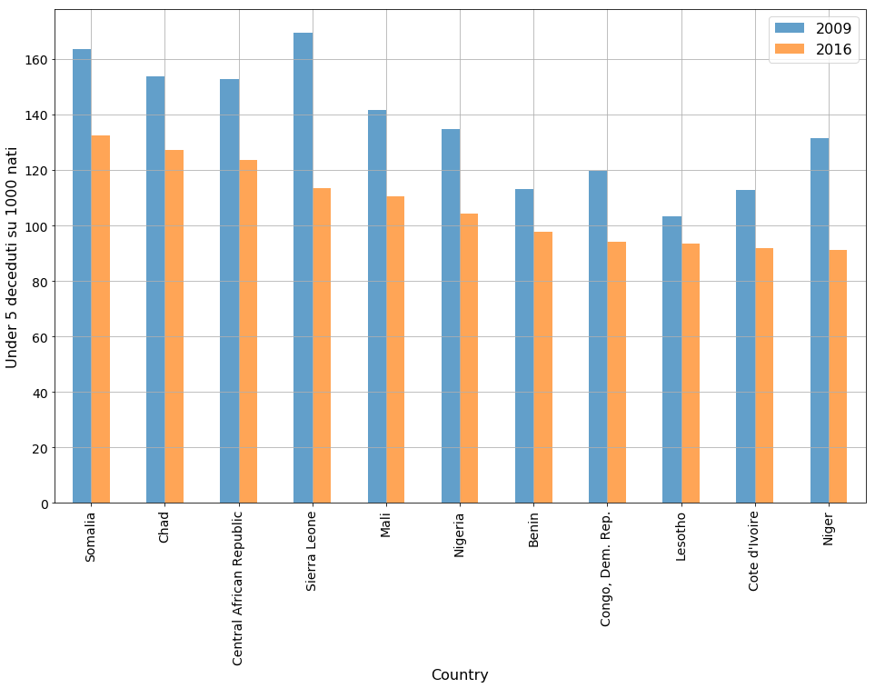

```python
ax = high_mort_rate_09_16.iloc[:11,:].plot.bar(figsize=(16,10), grid = True, alpha=0.7);
ax.set_ylabel('Under 5 deceduti su 1000 nati', fontsize=16)
ax.tick_params(axis='both', labelsize=14)
ax.set_xlabel('Country',fontsize=16);
ax.legend(prop={'size': 16});
```